# Solutions to Applied Predictive Modeling (Kuhn and Johnson, 2013)

Chapter 16 - Exercise 16.2

by Brian Hassett

# Introduction

This notebook outlines a solution to the exercise using the `tidymodels` package to implement the modeling. Also included is a brief exploratory data analysis. Three models are used: logistic regression; flexible discriminant analysis (FDA); and random forests. I have limited the number of models used and the size of the tuning grids to keep computation time low. The `tidymodels` framework easily allows for expansion of both if desired.

# Exercise Instructions

*Instructions adapted from Kuhn and Johnson (2013)[^1].*

This exercise explores the direct marketing data of Larose (2006, Chap. 7)[^2]. The goal of the original analysis was to predict which customers would respond to a promotional opportunity via mail. Of the 65,220 customers in the data set, 16.6% responded to the promotion. The predictors in the data set include

- Spending habits, in aggregate and broken down by month and frequently visited store locations
- The types of products purchased
- Time between visits
- Historical promotion response rates
- Predefined customer cluster memberships

Larose (2006) discussed the class imbalance for this problem and demonstrates several techniques to achieve effective results.

1. Read the data into `R`, conduct exploratory analyses, and determine the best method for encoding the predictors.
2. Determine an appropriate split of the data and build several classification models for these data.
3. Construct lift plots to understand a possible strategy regarding how many customers should be contacted to capture an estimated 60% of responders.
4. Use sampling methods with several models. Do these models have better lift charts, and can they be used to contact fewer customers to achieve a 60 % response rate (of those who were given the promotion)?

# Setup

```r
# Load packages
library(AppliedPredictiveModeling)
library(caret)
library(tidyverse)
library(tidymodels)
library(discrim)
library(ggcorrplot)
library(pROC)

# Load my functions:
source("/home/brian/R/dir/Util/bh_functions.R")

# Options:
theme_set(theme_bw())
options(digits = 4)
```

# Load and clean data

Load data from CSV file:

```r
df1 <- read.csv("/home/brian/R/dir/APM/chapter16/data/ClothingStore.txt")
df1
```

| HHKEY | ZIP_CODE | REC | FRE | MON | CC_CARD | AVRG | PC_CALC20 | PSWEATERS | PKNIT_TOPS | PKNIT_DRES | PBLOUSES | PJACKETS | PCAR_PNTS | PCAS_PNTS | PSHIRTS | PDRESSES | PSUITS | POUTERWEAR | PJEWELRY | PFASHION | PLEGWEAR | PCOLLSPND | AMSPEND | PSSPEND | CCSPEND | AXSPEND | TMONSPEND | OMONSPEND | SMONSPEND | … |
| --- | --- | --- | --- | --- | --- | --- | --- | --- | --- | --- | --- | --- | --- | --- | --- | --- | --- | --- | --- | --- | --- | --- | --- | --- | --- | --- | --- | --- | --- | --- |
| 9.956e+12 | 1001 | 208 | 2 | 368.46 | 0 | 184.23 | 11 | 0.180000 | 0.000000 | 0.000000 | 0.300000 | 0.00 | 0.250000 | 0.000000 | 0.190000 | 0.000000 | 0.00 | 0.000000 | 0.000000 | 0.020000 | 0.030000 | 0.290000 | 0.00 | 0.00 | 368.46 | 0.00 | 0.00 | 0.00 | 0.00 | … |
| 9.956e+12 | 1028 | 6 | 4 | 258.00 | 1 | 64.50 | 11 | 0.260000 | 0.160000 | 0.000000 | 0.000000 | 0.00 | 0.180000 | 0.140000 | 0.000000 | 0.180000 | 0.00 | 0.000000 | 0.000000 | 0.000000 | 0.020000 | 0.370000 | 0.00 | 0.00 | 258.00 | 0.00 | 138.00 | 55.99 | 258.00 | … |
| 9.956e+12 | 1056 | 327 | 2 | 77.00 | 0 | 38.50 | 11 | 1.000000 | 0.000000 | 0.000000 | 0.000000 | 0.00 | 0.000000 | 0.000000 | 0.000000 | 0.000000 | 0.00 | 0.000000 | 0.000000 | 0.000000 | 0.000000 | 0.000000 | 0.00 | 0.00 | 77.00 | 0.00 | 0.00 | 0.00 | 0.00 | … |
| 9.956e+12 | 1118 | 66 | 8 | 846.06 | 1 | 105.75 | 11 | 0.380000 | 0.000000 | 0.050000 | 0.060000 | 0.20 | 0.170000 | 0.000000 | 0.050000 | 0.000000 | 0.00 | 0.000000 | 0.005307 | 0.030000 | 0.010000 | 0.000000 | 0.00 | 0.00 | 846.06 | 0.00 | 104.94 | 0.00 | 373.87 | … |
| 9.956e+12 | 1107 | 49 | 1 | 87.44 | 0 | 87.44 | 11 | 0.200000 | 0.200000 | 0.000000 | 0.000000 | 0.00 | 0.000000 | 0.410000 | 0.000000 | 0.000000 | 0.00 | 0.000000 | 0.170000 | 0.000000 | 0.000000 | 0.000000 | 0.00 | 0.00 | 87.44 | 0.00 | 87.44 | 0.00 | 87.44 | … |
| 9.956e+12 | 1106 | 26 | 2 | 120.00 | 0 | 60.00 | 11 | 0.000000 | 0.560000 | 0.000000 | 0.000000 | 0.00 | 0.000000 | 0.000000 | 0.000000 | 0.000000 | 0.00 | 0.000000 | 0.020000 | 0.400000 | 0.000000 | 0.000000 | 0.00 | 58.00 | 62.00 | 0.00 | 62.00 | 62.00 | 120.00 | … |
| 9.956e+12 | 1108 | 98 | 3 | 450.98 | 0 | 150.32 | 11 | 0.160000 | 0.060000 | 0.000000 | 0.000000 | 0.36 | 0.140000 | 0.120000 | 0.000000 | 0.000000 | 0.00 | 0.000000 | 0.020000 | 0.110000 | 0.000000 | 0.000000 | 0.00 | 0.00 | 450.98 | 0.00 | 0.00 | 0.00 | 245.48 | … |
| 9.956e+12 | 1106 | 64 | 5 | 521.20 | 1 | 104.24 | 11 | 0.160000 | 0.070000 | 0.000000 | 0.050000 | 0.23 | 0.000000 | 0.070000 | 0.060000 | 0.250000 | 0.00 | 0.000000 | 0.020000 | 0.000000 | 0.010000 | 0.000000 | 0.00 | 0.00 | 521.20 | 0.00 | -28.72 | 0.00 | 357.22 | … |
| 9.956e+12 | 1118 | 145 | 1 | 782.08 | 1 | 782.08 | 11 | 0.120000 | 0.000000 | 0.000000 | 0.000000 | 0.57 | 0.120000 | 0.000000 | 0.170000 | 0.000000 | 0.00 | 0.000000 | 0.000000 | 0.000000 | 0.000000 | 0.000000 | 0.00 | 0.00 | 782.08 | 0.00 | 0.00 | 0.00 | 782.08 | … |
| 9.956e+12 | 1106 | 356 | 1 | 79.00 | 0 | 79.00 | 11 | 0.000000 | 0.000000 | 0.000000 | 0.000000 | 0.00 | 0.000000 | 1.000000 | 0.000000 | 0.000000 | 0.00 | 0.000000 | 0.000000 | 0.000000 | 0.000000 | 0.000000 | 0.00 | 0.00 | 79.00 | 0.00 | 0.00 | 0.00 | 0.00 | … |

[output cut: 990 more lines]

## Fix Duplicate columns

There are 53 columns in this data set, but Larose (2006) mentions 51 variables. This means that there are two extra variables in this data set:

1. The `AVRG` variable is the same as the `Sales.per.Visit` variable (allowing a small tolerance):

```r
df1 %>%
  select(AVRG, Sales.per.Visit) %>%
  mutate(same = near(AVRG, Sales.per.Visit, tol = 0.01)) %>%
  count(same)
```

|  | same | n |
| --- | --- | --- |
| 1 | TRUE | 28799 |

2. The `Tot_Spend` variable is the same as the `MON` variable (allowing a small tolerance):

```r
df1 %>%
  select(MON, Tot_Spend) %>%
  mutate(same = near(MON, Tot_Spend, tol = 0.005)) %>%
  count(same)
```

|  | same | n |
| --- | --- | --- |
| 1 | TRUE | 28799 |

I will remove the `Sales.per.Visit` and `Tot_Spend` variables since they are duplicates.

## Clean data

```r
# Reload data:
df1 <- read.csv("/home/brian/R/dir/APM/chapter16/data/ClothingStore.txt")

# Remove duplicate variables:
df1 <- dplyr::select(df1, -Sales.per.Visit, -Tot_Spend)

# Remove variables with no information:
# (on page 272 of Larose (2006) the author recommends removing ZIP_CODE even though it could be used as a categorical variable)
df1 <- dplyr::select(df1, -HHKEY, -ZIP_CODE)

# Convert categorical and flag variable to factors:
df1 <- df1 %>%
  mutate(CLUSTYPE = factor(CLUSTYPE),
         CC_CARD = factor(CC_CARD),
         VALPHON = factor(VALPHON),
         WEB = factor(WEB),
         RESP = factor(RESP))

# Round the negative percentages up to zero as per Larose (2006):
percent_vars <- c("PBLOUSES", "PCAR_PNTS", "PCAS_PNTS", "PDRESSES", "PFASHION", "PJACKETS", "PJEWELRY", "PKNIT_DRES", "PKNIT_TOPS", "PLEGWEAR", "POUTERWEAR", "PREVPD", "PSHIRTS", "PSUITS", "PSWEATERS")
df1 <- df1 %>%
  mutate(across(all_of(percent_vars), ~if_else(.x < 0, 0, .x)))
```

# Exploratory Data Analysis

## Summary

```r
bh_print_data_summary(df1)
```

```
                      [,1]
num_rows              "   28,799"
num_cols              "       49"
num_categorical_cols  "        5"
num_numeric_cols      "       44"
all_missing_cols      "        0"
complete_cols         "       48"
total_missing         "    1,727"
total_percent_missing "        0"
total_data_points     "1,409,424"
size_MB               "        9"
```

## Missing data

Only one variable (`STYLES`) is missing data:

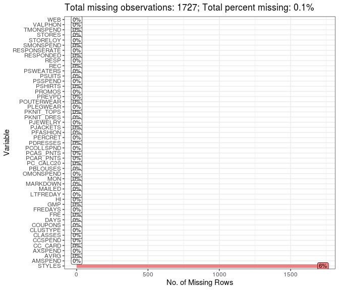

```r
bh_plot_missing(df1)
```

## Response Variable

Plotting the breakdown of the response variable, `RESP`, shows that the classes are imbalanced:

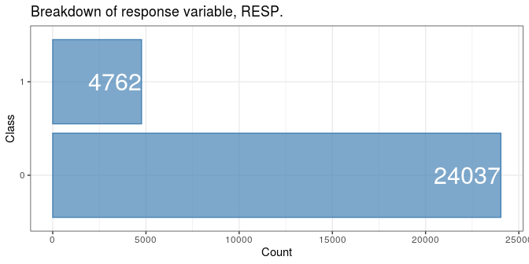

```r
df1 %>%
  count(RESP) %>%
  ggplot() +
  geom_col(aes(RESP, n),
           fill = "steelblue", color = "steelblue", alpha = 0.7) +
  geom_text(aes(RESP, n, label = n),
            hjust = 1, size = 8,
            color = "white") +
  labs(x = "Class", y = "Count", title = "Breakdown of response variable, RESP.") +
  coord_flip()
```

Table of counts and proportions for response variable, `RESP`:

```r
df1 %>%
  count(RESP) %>%
  mutate(prop = 100*n/sum(n))
```

|  | RESP | n | prop |
| --- | --- | --- | --- |
| 1 | 0 | 24037 | 83.46 |
| 2 | 1 | 4762 | 16.54 |

We see that the proportion of responses was about 16.6% as mentioned in the exercise.

## Categorical variables

I will plot the `CLUSTYPE` variable separately as there are quite a few classes.

Plot bar plots of the binary flag variables:

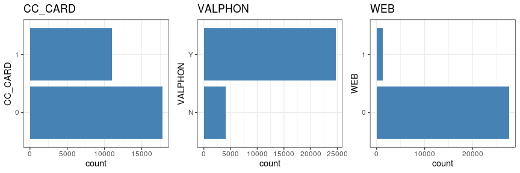

```r
bh_plot_bar_grid(df1[ , bh_categorical_cols(df1)[-c(4, 5)]], # exclude CLUSTYPE and RESP
                 nrow = 1,
                 flip = TRUE)
```

### `CLUSTYPE`

Plot the top 15 (of 51) `CLUSTYPE` levels:

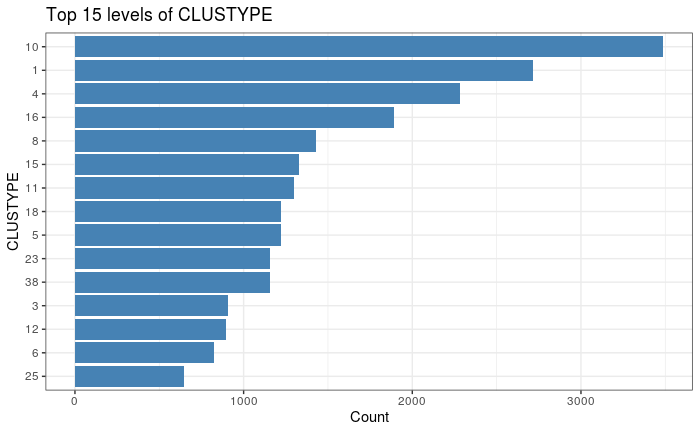

```r
df1 %>%
  count(CLUSTYPE) %>%
  slice_max(order_by = n, n = 15) %>%
  ggplot() +
  geom_col(aes(reorder(CLUSTYPE, n), n), fill = "steelblue") +
  labs(x = "CLUSTYPE", y = "Count", title = "Top 15 levels of CLUSTYPE") +
  coord_flip()
```

## Numeric variables

Histograms of numeric variables:

```
Removed 1727 rows containing non-finite values (stat_bin).
```

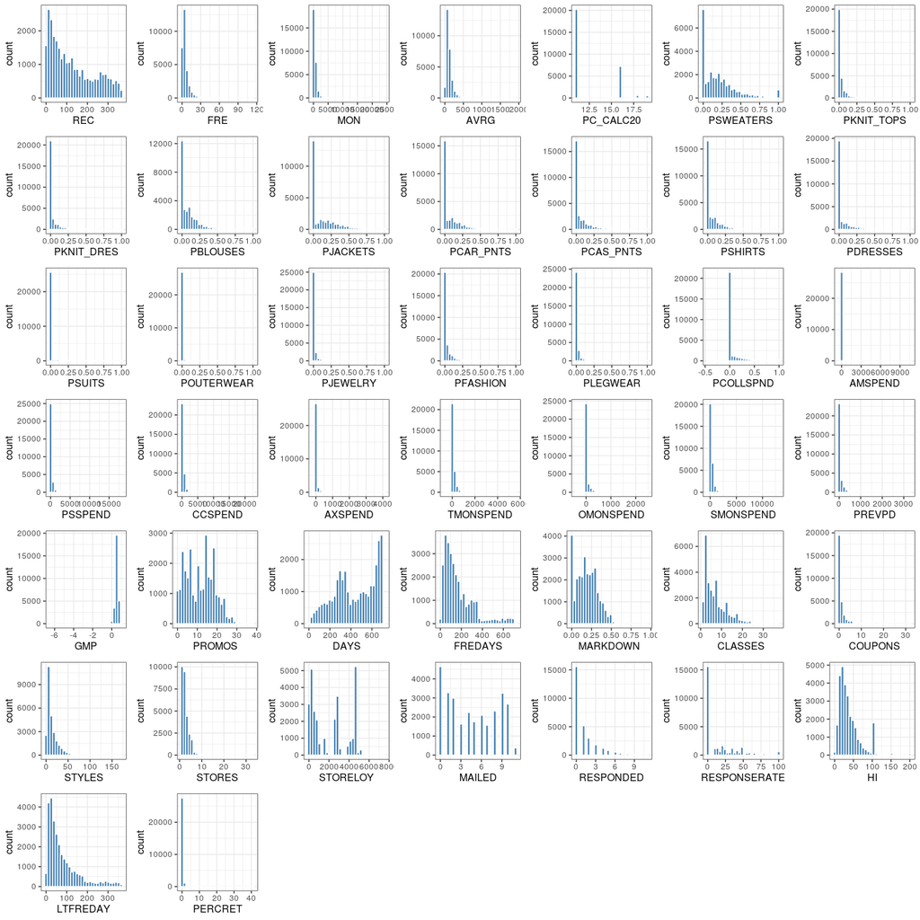

```r
bh_plot_histogram_grid(df1)
```

### Correlations

There are some highly correlated variables. These will be filtered out during preprocessing.

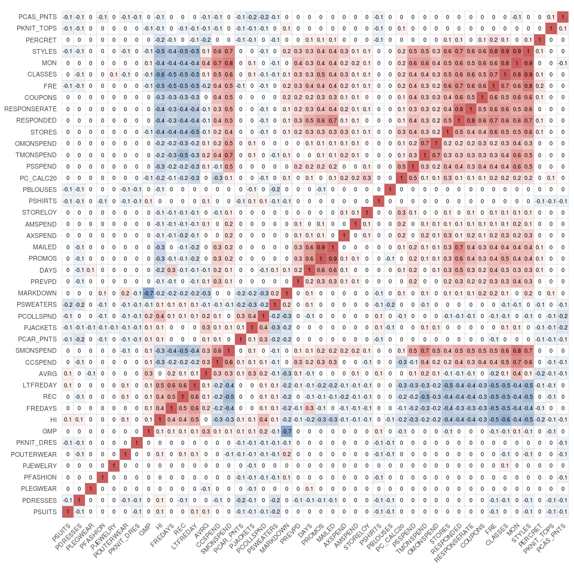

```r
correlations <- cor(na.omit(df1[ , bh_numeric_cols(df1)], ))
ggcorrplot(correlations, hc.order = TRUE, show.legend = F,
                 colors = c("steelblue", "white", "indianred"),
                 lab = TRUE, lab_size = 2.5, digits = 1, tl.cex = 8)
```

For data splitting I will use a train/test split. For modeling I will use logistic regression, flexible discriminant analysis and random forests. I will use down- and up-sampling with all three of these models.

# Data Splitting

Larose (2006) uses a 75%/25% training/test data split. I will do the same here.

```r
set.seed(123)

# Initial split of the data into test set and non-test set:
n <- nrow(df1)
split1 <- initial_split(df1,
                        strata = RESP,
                        prop = 0.75)
df_train  <- training(split1) # this is the training set (21,600 rows)
df_test <- testing(split1) # this is the test set (7,199 rows)

# Create folds for CV using the training data:
# (only 5 folds are used for now to lower computation time)
folds <- vfold_cv(data = df_train, v = 5, strata = RESP)
```

# Standard Modeling Methods

## Logistic Regression

For preprocessing, I will convert the categorical variables to dummy variables. I will remove near-zero variance variables and highly correlated variables. I have also used KNN imputation for missing data. No resampling is required for this model. I will just `fit()` a model on the training data and make predictions on the test data.

### Training set

```r
# Preprocessing
rec1 <-
  recipe(RESP ~ ., data = df_train) %>%
  step_center(all_numeric()) %>%
  step_scale(all_numeric()) %>%
  step_dummy(all_nominal(), -all_outcomes()) %>%
  step_nzv(all_predictors(), ) %>%
  step_corr(all_numeric(), threshold = 0.8) %>%
  step_knnimpute(all_predictors())

# Model
log_reg_mod1 <-
  logistic_reg() %>%
  set_mode("classification") %>%
  set_engine("glm")

# Workflow
workflow <-
  workflow() %>%
  add_model(spec = log_reg_mod1) %>%
  add_recipe(rec1)

# Fit
## Read in cached results if available:
file1 <- "/home/brian/R/dir/APM/chapter16/objects/log_reg_fit_16.2.RDS"
if (file.exists(file1)) {
  log_reg_fit <- readRDS(file1)
} else {
  log_reg_fit <-
    workflow %>%
    fit(data = df_train)
  saveRDS(log_reg_fit, file1)
}

# View fit:
tidy(log_reg_fit)
```

| term | estimate | std.error | statistic | p.value |
| --- | --- | --- | --- | --- |
| (Intercept) | -3.185968 | 0.09416 | -33.8363 | 5.779e-251 |
| REC | -0.017438 | 0.04009 | -0.4349 | 6.636e-01 |
| FRE | 0.358111 | 0.03986 | 8.9836 | 2.621e-19 |
| AVRG | -0.087875 | 0.03545 | -2.4786 | 1.319e-02 |
| PC_CALC20 | -0.042948 | 0.02526 | -1.7001 | 8.911e-02 |
| PSWEATERS | 0.030526 | 0.03011 | 1.0136 | 3.107e-01 |
| PKNIT_TOPS | -0.051324 | 0.02812 | -1.8251 | 6.798e-02 |
| PBLOUSES | 0.021699 | 0.02713 | 0.7998 | 4.238e-01 |
| PJEWELRY | -0.003873 | 0.02721 | -0.1423 | 8.868e-01 |
| PFASHION | -0.015701 | 0.02855 | -0.5500 | 5.823e-01 |

[output cut: 24 more lines]

### Test set

```r
# Fit final model on all of the training data and make predictions on the test set:
## Read in cached results if available:
file1 <- "/home/brian/R/dir/APM/chapter16/objects/log_reg_final_fit_test_16.2.RDS"
if (file.exists(file1)) {
  final_fit <- readRDS(file1)
} else {
  final_fit <-
    workflow %>%
    last_fit(split1)
  saveRDS(final_fit, file1)
}

# Collect predictions:
test_results <-
  final_fit %>%
  collect_predictions()
test_results$model <- "Logistic Regression"
```

## Flexible Discriminant Analysis

### Training data

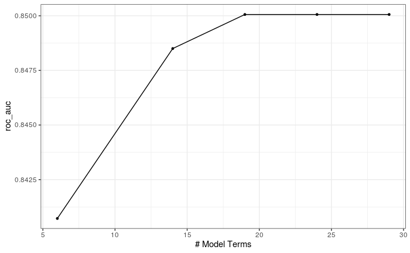

```r
# Preprocessing
rec1 <-
  recipe(RESP ~ ., data = df_train) %>%
  step_center(all_numeric()) %>%
  step_scale(all_numeric()) %>%
  step_dummy(all_nominal(), -all_outcomes()) %>%
  step_nzv(all_predictors()) %>%
  step_corr(all_numeric(), threshold = 0.8) %>%
  step_knnimpute(all_predictors())

# Model
fda_mod1 <-
  discrim_flexible(prod_degree = 1, num_terms = tune()) %>%
  set_mode("classification") %>%
  set_engine("earth")

# Workflow
workflow <-
  workflow() %>%
  add_model(spec = fda_mod1) %>%
  add_recipe(rec1)

# Tune
### Read in cached results if available:
file1 <- "/home/brian/R/dir/APM/chapter16/objects/fda_res1_16.2.RDS"
if (file.exists(file1)) {
  fda_res1 <- readRDS(file1)
} else {
  fda_res1 <-
    workflow %>%
    tune_grid(resamples = folds, grid = 5)
  saveRDS(fda_res1, file1)
}

# Plot accuracy:
### Line plot:
autoplot(fda_res1, metric = "roc_auc") +
  ggsci::scale_color_d3() +
  theme(legend.position = "top")
```

### Test set

Make predictions on the test set:

```r
# Select best model:
best_mod <- fda_res1 %>%
  select_best("roc_auc")

# Update final workflow:
final_wf <-
  workflow %>%
  finalize_workflow(best_mod)

# Fit final model on all of the training data and make predictions on the test set:
## Read in cached results if available:
file1 <- "/home/brian/R/dir/APM/chapter16/objects/fda_final_fit_test_16.2.RDS"
if (file.exists(file1)) {
  final_fit <- readRDS(file1)
} else {
  final_fit <-
    final_wf %>%
    last_fit(split1)
  saveRDS(final_fit, file1)
}

# Collect predictions:
test_results <-
  rbind(
    test_results,
    cbind(
      final_fit %>%
        collect_predictions(),
      model = "FDA"
    )
  )
```

## Random Forest

### Training set

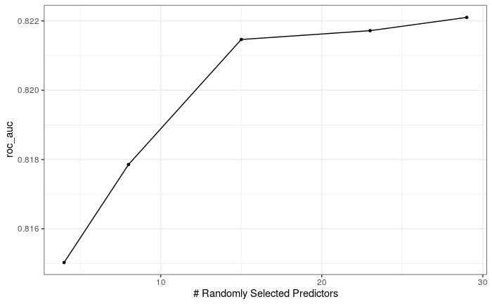

```r
# Preprocessing
rec1 <-
  recipe(RESP ~ ., data = df_train) %>%
  step_center(all_numeric()) %>%
  step_scale(all_numeric()) %>%
  step_dummy(all_nominal(), -all_outcomes()) %>%
  step_nzv(all_predictors()) %>%
  step_corr(all_numeric(), threshold = 0.8) %>%
  step_knnimpute(all_predictors())

# Model
rf_mod1 <-
  rand_forest(trees = 25, mtry = tune()) %>% # limit number of trees to keep comp. time down for now
  set_mode("classification") %>%
  set_engine("randomForest")

# Workflow
workflow <-
  workflow() %>%
  add_model(spec = rf_mod1) %>%
  add_recipe(rec1)

# Tune
## Read in cached results if available:
file1 <- "/home/brian/R/dir/APM/chapter16/objects/rf_res1_16.2.RDS"
if (file.exists(file1)) {
  rf_res1 <- readRDS(file1)
} else {
  rf_res1 <-
    workflow %>%
    tune_grid(
      resamples = folds,
      grid = 5
    )
  saveRDS(rf_res1, file1)
}

# Plot accuracy:
### Line plot:
autoplot(rf_res1, metric = "roc_auc") +
  ggsci::scale_color_d3() +
  theme(legend.position = "top")
```

### Test set

Make predictions on the test set:

```r
# Select best model:
best_mod <- rf_res1 %>%
  select_best("roc_auc")

# Update final workflow:
final_wf <-
  workflow %>%
  finalize_workflow(best_mod)

# Fit final model on all of the training data and make predictions on the test set:
## Read in cached results if available:
file1 <- "/home/brian/R/dir/APM/chapter16/objects/rf_final_fit_test_16.2.RDS"
if (file.exists(file1)) {
  final_fit <- readRDS(file1)
} else {
  final_fit <-
    final_wf %>%
    last_fit(split1)
  saveRDS(final_fit, file1)
}

# Collect predictions:
test_results <-
  rbind(
    test_results,
    cbind(
      final_fit %>%
        collect_predictions(),
      model = "Random Forest"
    )
  )
```

# Down-Sampling

I will use down sampling with all three models.

## Logistic Regression

### Training set

```r
# Preprocessing
rec1 <-
  recipe(RESP ~ ., data = df_train) %>%
  step_center(all_numeric()) %>%
  step_scale(all_numeric()) %>%
  step_dummy(all_nominal(), -all_outcomes()) %>%
  step_nzv(all_predictors()) %>%
  step_corr(all_numeric(), threshold = 0.8) %>%
  step_knnimpute(all_predictors()) %>%
  step_downsample(all_outcomes()) # just use the default ratio of 1
```

```
`step_downsample()` was deprecated in recipes 0.1.13.
Please use `themis::step_downsample()` instead.
```

```r
# Model
log_reg_mod1 <-
  logistic_reg() %>%
  set_mode("classification") %>%
  set_engine("glm")

# Workflow
workflow <-
  workflow() %>%
  add_model(spec = log_reg_mod1) %>%
  add_recipe(rec1)

# Fit
## Read in cached results if available:
file1 <- "/home/brian/R/dir/APM/chapter16/objects/log_reg_fit_DS_16.2.RDS"
if (file.exists(file1)) {
  log_reg_fit <- readRDS(file1)
} else {
  log_reg_fit <-
    workflow %>%
    fit(data = df_train)
  saveRDS(log_reg_fit, file1)
}

# View fit:
tidy(log_reg_fit)
```

| term | estimate | std.error | statistic | p.value |
| --- | --- | --- | --- | --- |
| (Intercept) | -1.544505 | 0.11428 | -13.51535 | 1.270e-41 |
| REC | 0.021271 | 0.05311 | 0.40054 | 6.888e-01 |
| FRE | 0.464644 | 0.07544 | 6.15918 | 7.312e-10 |
| AVRG | -0.055117 | 0.05102 | -1.08026 | 2.800e-01 |
| PC_CALC20 | -0.060535 | 0.03626 | -1.66928 | 9.506e-02 |
| PSWEATERS | 0.002942 | 0.03956 | 0.07437 | 9.407e-01 |
| PKNIT_TOPS | -0.008717 | 0.03663 | -0.23801 | 8.119e-01 |
| PBLOUSES | -0.008316 | 0.03582 | -0.23215 | 8.164e-01 |
| PJEWELRY | -0.011883 | 0.03836 | -0.30978 | 7.567e-01 |
| PFASHION | -0.033665 | 0.03696 | -0.91087 | 3.624e-01 |

[output cut: 24 more lines]

### Test set

```r
# Fit final model on all of the training data and make predictions on the test set:
## Read in cached results if available:
file1 <- "/home/brian/R/dir/APM/chapter16/objects/log_reg_final_fit_test_DS_16.2.RDS"
if (file.exists(file1)) {
  final_fit <- readRDS(file1)
} else {
  final_fit <-
    workflow %>%
    last_fit(split1)
  saveRDS(final_fit, file1)
}

# Collect predictions:
test_results <-
  rbind(
    test_results,
    cbind(
      final_fit %>%
        collect_predictions(),
      model = "Logistic Regression - Down Sampled"
    )
  )
```

## Flexible Discriminant Analysis

### Training data

```r
# Preprocessing
rec1 <-
  recipe(RESP ~ ., data = df_train) %>%
  step_center(all_numeric()) %>%
  step_scale(all_numeric()) %>%
  step_dummy(all_nominal(), -all_outcomes()) %>%
  step_nzv(all_predictors()) %>%
  step_corr(all_numeric(), threshold = 0.8) %>%
  step_knnimpute(all_predictors()) %>%
  step_downsample(all_outcomes()) # just use the default ratio of 1
```

```
`step_downsample()` was deprecated in recipes 0.1.13.
Please use `themis::step_downsample()` instead.
```

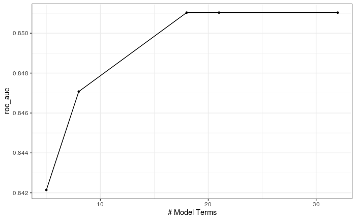

```r
# Model
fda_mod1 <-
  discrim_flexible(prod_degree = 1, num_terms = tune()) %>%
  set_mode("classification") %>%
  set_engine("earth")

# Workflow
workflow <-
  workflow() %>%
  add_model(spec = fda_mod1) %>%
  add_recipe(rec1)

# Tune
### Read in cached results if available:
file1 <- "/home/brian/R/dir/APM/chapter16/objects/fda_res1_DS_16.2.RDS"
if (file.exists(file1)) {
  fda_res1 <- readRDS(file1)
} else {
  fda_res1 <-
    workflow %>%
    tune_grid(resamples = folds, grid = 5)
  saveRDS(fda_res1, file1)
}

# Plot accuracy:
### Line plot:
autoplot(fda_res1, metric = "roc_auc") +
  ggsci::scale_color_d3() +
  theme(legend.position = "top")
```

### Test set

Make predictions on the test set:

```r
# Select best model:
best_mod <- fda_res1 %>%
  select_best("roc_auc")

# Update final workflow:
final_wf <-
  workflow %>%
  finalize_workflow(best_mod)

# Fit final model on all of the training data and make predictions on the test set:
## Read in cached results if available:
file1 <- "/home/brian/R/dir/APM/chapter16/objects/fda_final_fit_test_DS_16.2.RDS"
if (file.exists(file1)) {
  final_fit <- readRDS(file1)
} else {
  final_fit <-
    final_wf %>%
    last_fit(split1)
  saveRDS(final_fit, file1)
}

# Collect predictions:
test_results <-
  rbind(
    test_results,
    cbind(
      final_fit %>%
        collect_predictions(),
      model = "FDA - Down Sampled"
    )
  )
```

## Random Forest

### Training set

```r
# Preprocessing
rec1 <-
  recipe(RESP ~ ., data = df_train) %>%
  step_center(all_numeric()) %>%
  step_scale(all_numeric()) %>%
  step_dummy(all_nominal(), -all_outcomes()) %>%
  step_nzv(all_predictors()) %>%
  step_corr(all_numeric(), threshold = 0.8) %>%
  step_knnimpute(all_predictors()) %>%
  step_downsample(all_outcomes()) # just use the default ratio of 1
```

```
`step_downsample()` was deprecated in recipes 0.1.13.
Please use `themis::step_downsample()` instead.
```

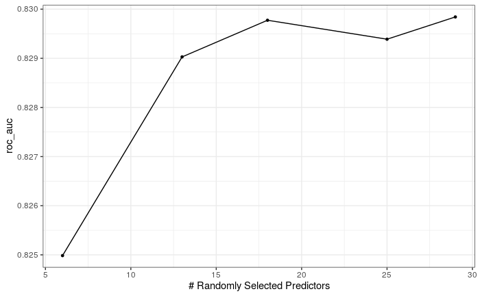

```r
# Model
rf_mod1 <-
  rand_forest(trees = 25, mtry = tune()) %>% # limit number of trees to keep comp. time down for now
  set_mode("classification") %>%
  set_engine("randomForest")

# Workflow
workflow <-
  workflow() %>%
  add_model(spec = rf_mod1) %>%
  add_recipe(rec1)

# Tune
## Read in cached results if available:
file1 <- "/home/brian/R/dir/APM/chapter16/objects/rf_res1_DS_16.2.RDS"
if (file.exists(file1)) {
  rf_res1 <- readRDS(file1)
} else {
  rf_res1 <-
    workflow %>%
    tune_grid(
      resamples = folds,
      grid = 5
    )
  saveRDS(rf_res1, file1)
}

# Plot accuracy:
### Line plot:
autoplot(rf_res1, metric = "roc_auc") +
  ggsci::scale_color_d3() +
  theme(legend.position = "top")
```

### Test set

Make predictions on the test set:

```r
# Select best model:
best_mod <- rf_res1 %>%
  select_best("roc_auc")

# Update final workflow:
final_wf <-
  workflow %>%
  finalize_workflow(best_mod)

# Fit final model on all of the training data and make predictions on the test set:
## Read in cached results if available:
file1 <- "/home/brian/R/dir/APM/chapter16/objects/rf_final_fit_test_DS_16.2.RDS"
if (file.exists(file1)) {
  final_fit <- readRDS(file1)
} else {
  final_fit <-
    final_wf %>%
    last_fit(split1)
  saveRDS(final_fit, file1)
}

# Collect predictions:
test_results <-
  rbind(
    test_results,
    cbind(
      final_fit %>%
        collect_predictions(),
      model = "Random Forest - Down Sampled"
    )
  )
```

# Up-Sampling

I will use up sampling with all three models.

## Logistic Regression

### Training set

```r
# Preprocessing
rec1 <-
  recipe(RESP ~ ., data = df_train) %>%
  step_center(all_numeric()) %>%
  step_scale(all_numeric()) %>%
  step_dummy(all_nominal(), -all_outcomes()) %>%
  step_nzv(all_predictors()) %>%
  step_corr(all_numeric(), threshold = 0.8) %>%
  step_knnimpute(all_predictors()) %>%
  step_upsample(all_outcomes()) # just use the default ratio of 1
```

```
`step_upsample()` was deprecated in recipes 0.1.13.
Please use `themis::step_upsample()` instead.
```

```r
# Model
log_reg_mod1 <-
  logistic_reg() %>%
  set_mode("classification") %>%
  set_engine("glm")

# Workflow
workflow <-
  workflow() %>%
  add_model(spec = log_reg_mod1) %>%
  add_recipe(rec1)

# Fit
## Read in cached results if available:
file1 <- "/home/brian/R/dir/APM/chapter16/objects/log_reg_fit_US_16.2.RDS"
if (file.exists(file1)) {
  log_reg_fit <- readRDS(file1)
} else {
  log_reg_fit <-
    workflow %>%
    fit(data = df_train)
  saveRDS(log_reg_fit, file1)
}

# View fit:
tidy(log_reg_fit)
```

| term | estimate | std.error | statistic | p.value |
| --- | --- | --- | --- | --- |
| (Intercept) | -1.4098243 | 0.05014 | -28.11979 | 5.613e-174 |
| REC | -0.0078890 | 0.02331 | -0.33842 | 7.350e-01 |
| FRE | 0.3933879 | 0.03101 | 12.68507 | 7.155e-37 |
| AVRG | -0.0538655 | 0.02145 | -2.51114 | 1.203e-02 |
| PC_CALC20 | -0.0705631 | 0.01587 | -4.44689 | 8.712e-06 |
| PSWEATERS | -0.0024647 | 0.01758 | -0.14019 | 8.885e-01 |
| PKNIT_TOPS | -0.0518240 | 0.01606 | -3.22759 | 1.248e-03 |
| PBLOUSES | 0.0087250 | 0.01620 | 0.53841 | 5.903e-01 |
| PJEWELRY | -0.0115829 | 0.01644 | -0.70455 | 4.811e-01 |
| PFASHION | -0.0349743 | 0.01645 | -2.12602 | 3.350e-02 |

[output cut: 24 more lines]

### Test set

```r
# Fit final model on all of the training data and make predictions on the test set:
## Read in cached results if available:
file1 <- "/home/brian/R/dir/APM/chapter16/objects/log_reg_final_fit_test_US_16.2.RDS"
if (file.exists(file1)) {
  final_fit <- readRDS(file1)
} else {
  final_fit <-
    workflow %>%
    last_fit(split1)
  saveRDS(final_fit, file1)
}

# Collect predictions:
test_results <-
  rbind(
    test_results,
    cbind(
      final_fit %>%
        collect_predictions(),
      model = "Logistic Regression - Up Sampled"
    )
  )
```

## Flexible Discriminant Analysis

### Training data

```r
# Preprocessing
rec1 <-
  recipe(RESP ~ ., data = df_train) %>%
  step_center(all_numeric()) %>%
  step_scale(all_numeric()) %>%
  step_dummy(all_nominal(), -all_outcomes()) %>%
  step_nzv(all_predictors()) %>%
  step_corr(all_numeric(), threshold = 0.8) %>%
  step_knnimpute(all_predictors()) %>%
  step_upsample(all_outcomes()) # just use the default ratio of 1
```

```
`step_upsample()` was deprecated in recipes 0.1.13.
Please use `themis::step_upsample()` instead.
```

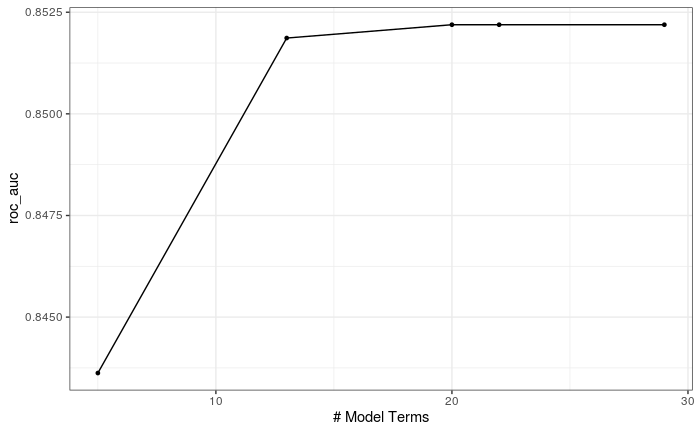

```r
# Model
fda_mod1 <-
  discrim_flexible(prod_degree = 1, num_terms = tune()) %>%
  set_mode("classification") %>%
  set_engine("earth")

# Workflow
workflow <-
  workflow() %>%
  add_model(spec = fda_mod1) %>%
  add_recipe(rec1)

# Tune
### Read in cached results if available:
file1 <- "/home/brian/R/dir/APM/chapter16/objects/fda_res1_US_16.2.RDS"
if (file.exists(file1)) {
  fda_res1 <- readRDS(file1)
} else {
  fda_res1 <-
    workflow %>%
    tune_grid(resamples = folds, grid = 5)
  saveRDS(fda_res1, file1)
}

# Plot accuracy:
### Line plot:
autoplot(fda_res1, metric = "roc_auc") +
  ggsci::scale_color_d3() +
  theme(legend.position = "top")
```

### Test set

Make predictions on the test set:

```r
# Select best model:
best_mod <- fda_res1 %>%
  select_best("roc_auc")

# Update final workflow:
final_wf <-
  workflow %>%
  finalize_workflow(best_mod)

# Fit final model on all of the training data and make predictions on the test set:
## Read in cached results if available:
file1 <- "/home/brian/R/dir/APM/chapter16/objects/fda_final_fit_test_US_16.2.RDS"
if (file.exists(file1)) {
  final_fit <- readRDS(file1)
} else {
  final_fit <-
    final_wf %>%
    last_fit(split1)
  saveRDS(final_fit, file1)
}

# Collect predictions:
test_results <-
  rbind(
    test_results,
    cbind(
      final_fit %>%
        collect_predictions(),
      model = "FDA - Up Sampled"
    )
  )
```

## Random Forest

### Training set

```r
# Preprocessing
rec1 <-
  recipe(RESP ~ ., data = df_train) %>%
  step_center(all_numeric()) %>%
  step_scale(all_numeric()) %>%
  step_dummy(all_nominal(), -all_outcomes()) %>%
  step_nzv(all_predictors()) %>%
  step_corr(all_numeric(), threshold = 0.8) %>%
  step_knnimpute(all_predictors()) %>%
  step_upsample(all_outcomes()) # just use the default ratio of 1
```

```
`step_upsample()` was deprecated in recipes 0.1.13.
Please use `themis::step_upsample()` instead.
```

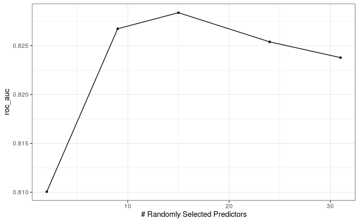

```r
# Model
rf_mod1 <-
  rand_forest(trees = 25, mtry = tune()) %>% # limit number of trees to keep comp. time down
  set_mode("classification") %>%
  set_engine("randomForest")

# Workflow
workflow <-
  workflow() %>%
  add_model(spec = rf_mod1) %>%
  add_recipe(rec1)

# Tune
## Read in cached results if available:
file1 <- "/home/brian/R/dir/APM/chapter16/objects/rf_res1_US_16.2.RDS"
if (file.exists(file1)) {
  rf_res1 <- readRDS(file1)
} else {
  rf_res1 <-
    workflow %>%
    tune_grid(
      resamples = folds,
      grid = 5
    )
  saveRDS(rf_res1, file1)
}

# Plot accuracy:
### Line plot:
autoplot(rf_res1, metric = "roc_auc") +
  ggsci::scale_color_d3() +
  theme(legend.position = "top")
```

### Test set

Make predictions on the test set:

```r
# Select best model:
best_mod <- rf_res1 %>%
  select_best("roc_auc")

# Update final workflow:
final_wf <-
  workflow %>%
  finalize_workflow(best_mod)

# Fit final model on all of the training data and make predictions on the test set:
## Read in cached results if available:
file1 <- "/home/brian/R/dir/APM/chapter16/objects/rf_final_fit_test_US_16.2.RDS"
if (file.exists(file1)) {
  final_fit <- readRDS(file1)
} else {
  final_fit <-
    final_wf %>%
    last_fit(split1)
  saveRDS(final_fit, file1)
}

# Collect predictions:
test_results <-
  rbind(
    test_results,
    cbind(
      final_fit %>%
        collect_predictions(),
      model = "Random Forest - Up Sampled"
    )
  )
```

# Metrics, ROC curves, Gain curves

Gain curves (APM refers to them as lift curves) and ROC curves are plotted in this section. I us ethe gain curves to estimate the number of samples required to be tested to identify at least 60% of responders. I also look at the accuracy and sensitivity of the models.

## Calculate Metrics

```r
get_metrics <- function(test_results, model) {
  test_results <- test_results %>%
    filter(model == {{ model }})

  metrics <- caret::confusionMatrix(data = test_results$.pred_class,
                                    reference = test_results$RESP,
                                    positive = "1")

  metrics$auc <-
    test_results %>%
    yardstick::roc_auc(RESP, .pred_1, event_level = "second") %>%
    pluck(".estimate")

  return(metrics)
}

models <- unique(test_results$model)
test_metrics <- map(models, ~get_metrics(test_results, .x)) %>%
  set_names(models)
```

## Inspect metrics

AUC:

```r
bh_display_metric <- function(metrics, type = "Metric") { # metrics is a named vector of doubles
  M <- matrix(metrics)
  dimnames(M) <- list(names(metrics), type)
  return(M)
}
bh_display_metric(map_dbl(test_metrics, ~.x$auc) %>% sort(decreasing = T), type = "Test AUC")
```

```
                                   Test AUC
FDA - Down Sampled                   0.8505
FDA - Up Sampled                     0.8501
FDA                                  0.8468
Logistic Regression                  0.8383
Logistic Regression - Up Sampled     0.8371
Logistic Regression - Down Sampled   0.8360
Random Forest - Down Sampled         0.8269
Random Forest - Up Sampled           0.8216
Random Forest                        0.8198
```

Accuracy:

```r
bh_display_metric(map_dbl(test_metrics, ~.x$overall[1]) %>% sort(decreasing = T), type = "Test Accuracy")
```

```
                                   Test Accuracy
FDA                                       0.8525
Logistic Regression                       0.8489
Random Forest                             0.8460
Random Forest - Up Sampled                0.8373
FDA - Down Sampled                        0.7359
FDA - Up Sampled                          0.7312
Random Forest - Down Sampled              0.7230
Logistic Regression - Down Sampled        0.7075
Logistic Regression - Up Sampled          0.7036
```

Sensitivity:

```r
bh_display_metric(map_dbl(test_metrics, ~.x$byClass[1]) %>% sort(decreasing = T), type = "Test Sensitivity")
```

```
                                   Test Sensitivity
Logistic Regression - Up Sampled             0.8378
Logistic Regression - Down Sampled           0.8294
FDA - Up Sampled                             0.8193
FDA - Down Sampled                           0.8076
Random Forest - Down Sampled                 0.7916
Random Forest - Up Sampled                   0.4034
FDA                                          0.3731
Random Forest                                0.3059
Logistic Regression                          0.2134
```

Confusion matrices for the test set:

```r
map(test_metrics, ~.x$table)
```

```
$`Logistic Regression`
          Reference
Prediction    0    1
         0 5857  936
         1  152  254

$FDA
          Reference
Prediction    0    1
         0 5693  746
         1  316  444

$`Random Forest`
          Reference
Prediction    0    1
         0 5726  826
         1  283  364

$`Logistic Regression - Down Sampled`
          Reference
Prediction    0    1
         0 4106  203
         1 1903  987

$`FDA - Down Sampled`
          Reference
Prediction    0    1
         0 4337  229
         1 1672  961

$`Random Forest - Down Sampled`
          Reference
Prediction    0    1
         0 4263  248
         1 1746  942

$`Logistic Regression - Up Sampled`
          Reference
Prediction    0    1
         0 4068  193
         1 1941  997

$`FDA - Up Sampled`
          Reference
Prediction    0    1
         0 4289  215
         1 1720  975

$`Random Forest - Up Sampled`
          Reference
Prediction    0    1
         0 5548  710
         1  461  480
```

## ROC Curves

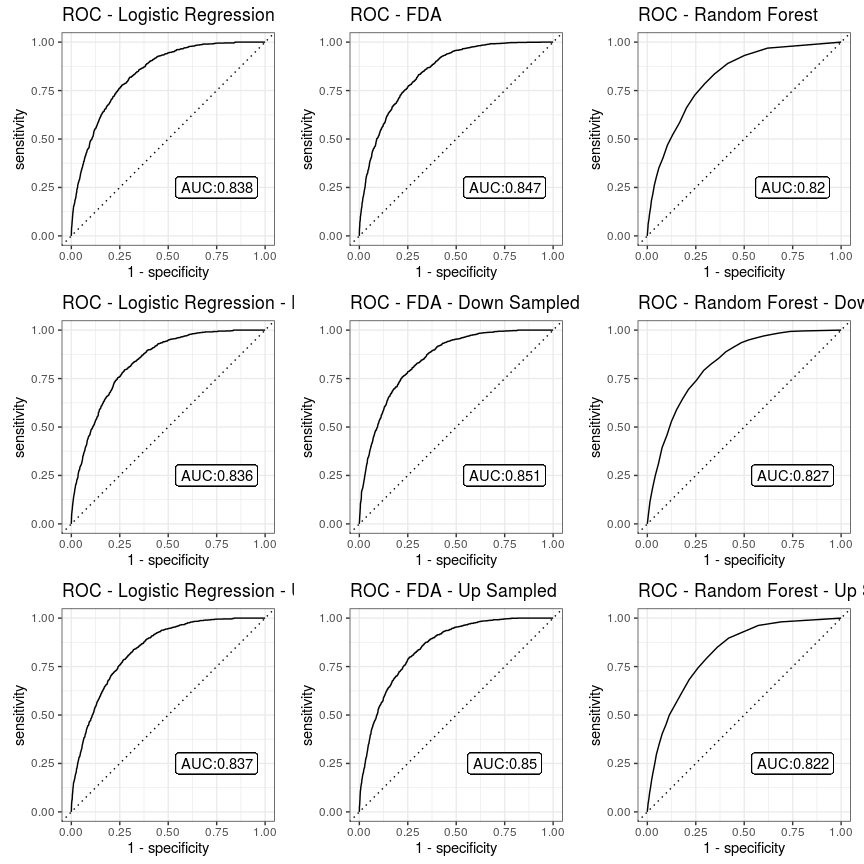

```r
# This function plots an ROC curve using the `yardstick` package:
plot_roc_curve <- function(test_results, model) {

  # Get AUC for labeling the plot:
  auc <- test_metrics[[{{ model }}]]$auc

  # ROC curve:
  p <- test_results %>%
    filter(model == {{ model }}) %>%
    yardstick::roc_curve(RESP, .pred_1, event_level = "second") %>%
    autoplot() +
    geom_label(aes(x = 0.75, y = 0.25, label = paste0("AUC:", round(auc, 3)))) +
    ggtitle(paste0("ROC - ", {{ model }}))
  return(p)
}

cowplot::plot_grid(
  plotlist = map(models, ~plot_roc_curve(test_results, .x)),
  nrow = 3
)
```

## Gain Curves

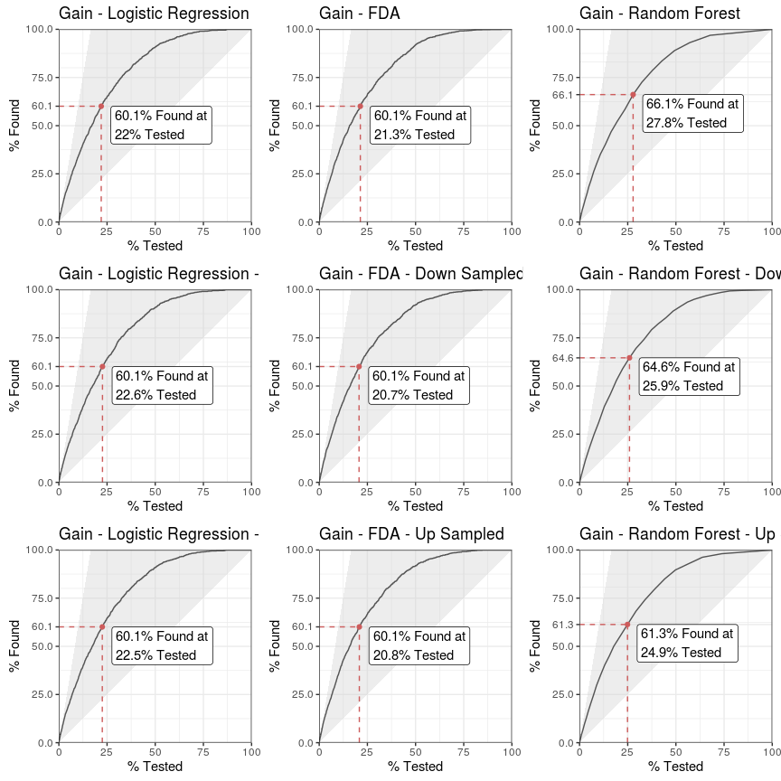

```r
# This function plots a gain curve using the `yardstick` package.
# I have included an option to include a "found" percentage with corresponding "tested" percentage
# marked on the plot.
plot_gain_curve <- function(test_results, model, percentage = NULL) {

  # Gain curve data:
  gain_data <- test_results %>%
    filter(model == {{ model }}) %>%
    yardstick::gain_curve(RESP, .pred_1, event_level = "second")

  # If a percentage is supplied then find the corresponding "tested" percentage:
  if(!is.null(percentage)) {
    capture_percentage <- gain_data %>%
      filter(.percent_found > percentage) %>%
      head(1)
  }

  # Gain curve:
  p <- gain_data %>%
    autoplot() +
    ggtitle(paste0("Gain - ", {{ model }}))

  if(!is.null(percentage)) {
    p <- p +
      geom_segment(data = capture_percentage, # vertical line
               aes(x = .percent_tested, xend = .percent_tested,
                   y = 0, yend = .percent_found),
               color = "indianred", linetype = "dashed") +
      geom_segment(data = capture_percentage, # horizontal line
                   aes(x = 0, xend = .percent_tested,
                       y = .percent_found, yend = .percent_found),
                   color = "indianred", linetype = "dashed") +
      geom_point(data = capture_percentage, aes(.percent_tested, .percent_found),
                 color = "indianred") +
      geom_label(data = capture_percentage,
                 aes(x = .percent_tested, .percent_found,
                     label = paste0(round(.percent_found, 1), "% Found at\n", round(.percent_tested, 1), "% Tested")),
                 hjust = 0, vjust = 1, nudge_x = 5) +
      scale_y_continuous(breaks = c(seq(0, 100, 25), round(capture_percentage$.percent_found, 1))) +
      coord_fixed(expand = F)
  }

  return(p)
}

cowplot::plot_grid(
  plotlist = map(models, ~plot_gain_curve(test_results, .x, percentage = 60)),
  nrow = 3
)
```

[^1]: Kuhn M, Johnson K (2013). *Applied Predictive Modeling*. Springer.
[^2]: Larose D (2006). *Data Mining Methods and Models*. Wiley.